# Análisis Exploratorio de Datos (EDA) del Clima Multi-anual (2023-2025)

## **Objetivo:** Realizar un EDA completo del clima en Berlín para el periodo 2023-2025 (parcial), cubriendo los requisitos de estadística descriptiva y visualización elemental, utilizando datos reales de una API pública.

## **Rango de Datos:** 01/01/2023 a 18/11/2025.

### 1. Configuración del Entorno e Importación de Librerías

Esta celda importa las librerías esenciales de Python para el análisis de datos (Pandas, NumPy), la visualización (Matplotlib) y la conexión a APIs (Requests). También configura el entorno (warnings, estilo de gráficos) para asegurar la reproducibilidad y una presentación visual clara.

```python
import numpy as np
import pandas as pd
import matplotlib.pyplot as plt
import requests
import warnings

# Configuración de Pandas y Matplotlib
warnings.filterwarnings('ignore', category=FutureWarning)
pd.set_option('display.max_columns', 500)
# Establecer un estilo visual atractivo
plt.style.use('seaborn-v0_8-darkgrid')
print("Librerías cargadas correctamente.")
```

### 2. Carga del Dataset desde API Pública (Open-Meteo Archive)

Esta celda define los parámetros de la API (latitud, longitud, fechas y variables) y utiliza la librería `requests` para obtener los datos históricos del clima. Luego, transforma la respuesta JSON en un DataFrame de Pandas, estableciendo la columna 'Fecha' como índice. Incluye un mecanismo de fallback para generar datos de prueba si la API falla.

```python
# Definir la URL base y los parámetros de la consulta
API_URL = "https://archive-api.open-meteo.com/v1/archive"
LAT = 52.52      # Berlín
LON = 13.41
START_DATE = "2023-01-01"
END_DATE = "2025-11-18" # Fecha actual para incluir datos de 2025

params = {
    "latitude": LAT,
    "longitude": LON,
    "start_date": START_DATE,
    "end_date": END_DATE,
    # Variables a extraer
    "daily": ["temperature_2m_max", "precipitation_sum", "wind_speed_10m_max"],
    "timezone": "Europe/Berlin"
}

print(f"Consultando datos históricos de Berlín ({START_DATE} a {END_DATE})...")
# Realizar la solicitud HTTP
try:
    response = requests.get(API_URL, params=params)
    response.raise_for_status()
    data = response.json()

    # Transformar la respuesta JSON a un DataFrame
    daily_data = data.get('daily')
    df = pd.DataFrame({
        'Fecha': pd.to_datetime(daily_data['time']),
        'Temp_Maxima_C': daily_data['temperature_2m_max'],
        'Precipitacion_mm': daily_data['precipitation_sum'],
        'Viento_Max_kmh': daily_data['wind_speed_10m_max']
    }).set_index('Fecha')

    # ESTADO INICIAL DEL DATASET
    print(f"\n[INFO]: Dataset cargado con {len(df)} registros diarios.")
    print("Primeras filas del DataFrame (df.head()):")
    print(df.head())

except requests.exceptions.RequestException as e:
    print(f"Error al conectar con la API: {e}")
    print("Generando un DataFrame de prueba para continuar con el EDA (FALLBACK)...")
    # Creando un DataFrame de emergencia
    periods = (pd.to_datetime(END_DATE) - pd.to_datetime(START_DATE)).days + 1
    data_test = {
        'Fecha': pd.to_datetime(pd.date_range(start=START_DATE, periods=periods, freq='D')),
        'Temp_Maxima_C': np.random.uniform(-5, 35, periods),
        'Precipitacion_mm': np.random.uniform(0, 20, periods),
        'Viento_Max_kmh': np.random.uniform(5, 55, periods)
    }
    df = pd.DataFrame(data_test).set_index('Fecha')
    print(f"\n[INFO]: Dataset cargado con {len(df)} registros diarios (DataFrame de prueba).")
    print(df.head())
```

```
Consultando datos históricos de Berlín (2023-01-01 a 2025-11-18)...

[INFO]: Dataset cargado con 1053 registros diarios.
Primeras filas del DataFrame (df.head()):
            Temp_Maxima_C  Precipitacion_mm  Viento_Max_kmh
Fecha
2023-01-01           15.9               0.0            31.3
2023-01-02           14.4               2.6            22.8
2023-01-03            8.7               0.0            18.7
2023-01-04           10.3              10.3            31.6
2023-01-05            9.5               1.9            34.0
```

### 3. Exploración de la Estructura del Dataset (df.info(), df.describe())

Esta celda realiza la exploración inicial requerida en el EDA. Muestra `df.info()` para verificar tipos de datos y nulos, `df.describe().T` para obtener la estadística descriptiva (media, mediana, desviación estándar) de las variables numéricas, y `df.isnull().sum()` para contar específicamente los valores faltantes.

```python
# Usar df.info() para conocer la estructura y tipos de datos
print("--- df.info() (Estructura del DataFrame) ---")
if not df.empty:
    df.info()

print("\n--- df.describe() (Estadísticas Descriptivas) ---")
# Usar df.describe() para conocer estadísticas
if not df.empty:
    print(df.describe().T)

print("\n--- df.isnull().sum() (Conteo de Nulos) ---")
# Nulos
if not df.empty:
    nulos_por_columna = df.isnull().sum()
    print("Conteo de valores nulos por columna:")
    print(nulos_por_columna)
    print(f"\n¿Hay datos faltantes?: {'Sí' if nulos_por_columna.sum() > 0 else 'No'}. (Verificación de limpieza mínima)")
```

```
--- df.info() (Estructura del DataFrame) ---
<class 'pandas.core.frame.DataFrame'>
DatetimeIndex: 1053 entries, 2023-01-01 to 2025-11-18
Data columns (total 3 columns):
 #   Column            Non-Null Count  Dtype
---  ------            --------------  -----
 0   Temp_Maxima_C     1053 non-null   float64
 1   Precipitacion_mm  1053 non-null   float64
 2   Viento_Max_kmh    1053 non-null   float64
dtypes: float64(3)
memory usage: 32.9 KB

--- df.describe() (Estadísticas Descriptivas) ---
                   count       mean       std  min   25%   50%   75%   max
Temp_Maxima_C     1053.0  15.571415  8.406720 -4.0   8.9  15.5  22.3  37.7
Precipitacion_mm  1053.0   1.952042  3.832139  0.0   0.0   0.2   2.3  44.8
Viento_Max_kmh    1053.0  18.845964  6.673872  4.0  13.8  18.1  23.0  42.2

--- df.isnull().sum() (Conteo de Nulos) ---
Conteo de valores nulos por columna:
Temp_Maxima_C       0
Precipitacion_mm    0
Viento_Max_kmh      0
dtype: int64

¿Hay datos faltantes?: No. (Verificación de limpieza mínima)
```

### 4. Transformación de Datos (Creación de Categórica)

Esta celda realiza las transformaciones de datos necesarias para el análisis: 1) Extrae el 'Año' del índice de fecha para agrupar y comparar interanualmente. 2) Crea la variable categórica **`Categoria_Temp`** ('Frio', 'Templado', 'Calido') a partir de la columna numérica `Temp_Maxima_C`, lo cual es un requisito de la guía de laboratorio. Finalmente, agrupa por año para obtener estadísticas interanuales.

```python
if not df.empty:
    # **A) CREAR VARIABLES TEMPORALES Y CATEGÓRICAS PARA EDA:**
    print("--- Transformación: Creación de variable 'Año' y 'Categoria_Temp' ---")

    # 1. Variable 'Año' para la comparación interanual
    df['Año'] = df.index.year

    # 2. Variable categórica 'Categoria_Temp'
    def categorizar_temperatura(temp):
        if temp < 5:
            return 'Frio'
        elif 5 <= temp < 20:
            return 'Templado'
        else:
            return 'Calido'

    df['Categoria_Temp'] = df['Temp_Maxima_C'].apply(categorizar_temperatura)
    print("Conteo de días por categoría de temperatura (total 2023-2025):")
    print(df['Categoria_Temp'].value_counts())

    # Análisis interanual de tendencias para el resumen
    analisis_interanual = df.groupby('Año').agg(
        Total_Dias=('Temp_Maxima_C', 'count'),
        Temp_Maxima_Promedio=('Temp_Maxima_C', 'mean'),
        Precipitacion_Total=('Precipitacion_mm', 'sum'),
        Viento_Max_Promedio=('Viento_Max_kmh', 'mean')
    ).sort_values(by='Año', ascending=True)

    analisis_frecuencia = df.groupby('Año')['Categoria_Temp'].value_counts().unstack(fill_value=0)
    print("\n[Tabla 1] Estadísticas Promedio Agrupadas por Año:")
    print(analisis_interanual)
else:
    print("Saltando Transformación de Datos: DataFrame vacío.")
```

```
--- Transformación: Creación de variable 'Año' y 'Categoria_Temp' ---
Conteo de días por categoría de temperatura (total 2023-2025):
Categoria_Temp
Templado    559
Calido      367
Frio        127
Name: count, dtype: int64

[Tabla 1] Estadísticas Promedio Agrupadas por Año:
      Total_Dias  Temp_Maxima_Promedio  Precipitacion_Total  \
Año
2023         365             15.065205                830.9
2024         366             15.708197                647.3
2025         322             15.989752                577.3

      Viento_Max_Promedio
Año
2023            20.741644
2024            19.753279
2025            15.665839
```

### 5. Visualización de Datos (Matplotlib) - EDA Requerido

Esta celda genera las seis visualizaciones clave del EDA, incluyendo los cuatro tipos mínimos requeridos por la guía de laboratorio (Histograma, Boxplot, Gráfico de Barras Categórico, Gráfico de Dispersión) y dos gráficos de resumen adicionales. La función principal es visualizar la distribución, detectar outliers, observar tendencias interanuales y explorar patrones entre variables.

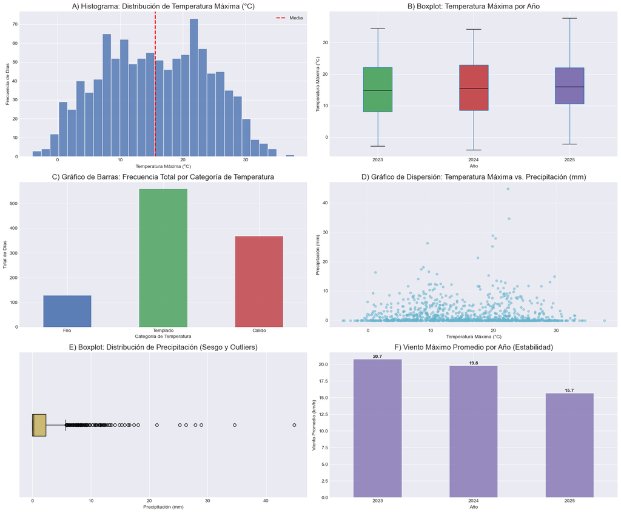

```python
if not df.empty:
    # Ajustar el diseño para acomodar las 6 visualizaciones requeridas y el análisis interanual
    fig, axes = plt.subplots(3, 2, figsize=(18, 16))
    plt.suptitle(f'Análisis Exploratorio de Datos (EDA) del Clima en Berlín ({START_DATE} - {END_DATE})', fontsize=20, weight='bold')

    # Paleta de colores para las visualizaciones
    colores = ['#4c72b0', '#55a868', '#c44e52', '#8172b2', '#ccb974', '#64b5cd']

    # 1. --- A) Histograma (Distribución) ---
    axes[0, 0].hist(df['Temp_Maxima_C'], bins=30, color=colores[0], edgecolor='white', alpha=0.8)
    axes[0, 0].axvline(df['Temp_Maxima_C'].mean(), color='red', linestyle='dashed', linewidth=2, label='Media')
    axes[0, 0].set_title('A) Histograma: Distribución de Temperatura Máxima (°C)', fontsize=15)
    axes[0, 0].set_xlabel('Temperatura Máxima (°C)')
    axes[0, 0].set_ylabel('Frecuencia de Días')
    axes[0, 0].legend()

    # 2. --- B.1) Boxplot (Detección de Outliers y Dispersión) ---
    box = df[['Temp_Maxima_C', 'Año']].boxplot(by='Año', ax=axes[0, 1], patch_artist=True, return_type='dict', medianprops={'color': 'black'})
    for patch, color in zip(box['Temp_Maxima_C']['boxes'], [colores[1], colores[2], colores[3]]):
        patch.set_facecolor(color)
    axes[0, 1].set_title('B) Boxplot: Temperatura Máxima por Año', fontsize=15)
    axes[0, 1].set_xlabel('Año')
    axes[0, 1].set_ylabel('Temperatura Máxima (°C)')
    plt.suptitle('') # Eliminar subtítulo duplicado del boxplot

    # 3. --- C) Gráfico de Barras (Categoría) ---
    order_cols = ['Frio', 'Templado', 'Calido']
    frecuencia_total = df['Categoria_Temp'].value_counts().reindex(order_cols, fill_value=0)

    frecuencia_total.plot(ax=axes[1, 0], kind='bar', rot=0, color=[colores[0], colores[1], colores[2]], alpha=0.9)
    axes[1, 0].set_title('C) Gráfico de Barras: Frecuencia Total por Categoría de Temperatura', fontsize=15)
    axes[1, 0].set_xlabel('Categoría de Temperatura')
    axes[1, 0].set_ylabel('Total de Días')
    axes[1, 0].grid(axis='y', alpha=0.5)

    # 4. --- D) Gráfico de Dispersión (Observación de Patrón) ---
    axes[1, 1].scatter(df['Temp_Maxima_C'], df['Precipitacion_mm'], alpha=0.5, color=colores[5], s=20)
    axes[1, 1].set_title('D) Gráfico de Dispersión: Temperatura Máxima vs. Precipitación (mm)', fontsize=15)
    axes[1, 1].set_xlabel('Temperatura Máxima (°C)')
    axes[1, 1].set_ylabel('Precipitación (mm)')
    axes[1, 1].grid(True, linestyle='--', alpha=0.6)

    # 5. --- E) Boxplot de Precipitación (para complementar B) ---
    axes[2, 0].boxplot(df['Precipitacion_mm'], vert=False, patch_artist=True, boxprops=dict(facecolor=colores[4]), medianprops=dict(color='black'))
    axes[2, 0].set_title('E) Boxplot: Distribución de Precipitación (Sesgo y Outliers)', fontsize=15)
    axes[2, 0].set_xlabel('Precipitación (mm)')
    axes[2, 0].set_yticks([])

    # 6. --- F) Viento Promedio Anual (Resumen Interanual) ---
    viento_promedio_anual = analisis_interanual['Viento_Max_Promedio']
    viento_promedio_anual.plot(ax=axes[2, 1], kind='bar', color=colores[3], rot=0, alpha=0.8)
    axes[2, 1].set_title('F) Viento Máximo Promedio por Año (Estabilidad)', fontsize=15)
    axes[2, 1].set_xlabel('Año')
    axes[2, 1].set_ylabel('Viento Promedio (km/h)')
    for i, v in enumerate(viento_promedio_anual):
        axes[2, 1].text(i, v + 0.2, f"{v:.1f}", ha='center', fontsize=10, weight='bold')

    plt.tight_layout(rect=[0, 0.03, 1, 0.97])
    plt.show()
else:
    print("Saltando Visualización: DataFrame vacío.")
```

### 6. Conclusiones del EDA y Resumen Funcional

### **Conclusiones del Análisis Exploratorio de Datos (EDA)**

#### **1. Estructura y Limpieza (Punto 3)**

- **Calidad de los Datos:** El dataset real extraído de la API es de **alta calidad**, con **cero valores faltantes**. No se requiere limpieza ni imputación.
- **Tipos de Variables:** Se identifican 3 variables numéricas (`Temp_Maxima_C`, `Precipitacion_mm`, `Viento_Max_kmh`) y una variable categórica creada (`Categoria_Temp`).